# COVID19 - Forecast and predictions using a BYM model in Italy

Paolo Girardi

20 Marzo, 2020

This work is licensed under a [Creative Commons Attribution-NonCommercial 4.0 International License](http://creativecommons.org/licenses/by-nc/4.0/).

# Disclaimer

NB: to compile this file please download the Italian Shapefile from the repository  
and set the working directory here

```r
setwd("/Users/Paolo/My_Website/public/COVID19_SEIR_model")
```

## The COVID dataset

The present analysis started from the dataset on COVID19 updated in https://github.com/pcm-dpc/COVID-19, database provided by the Italian Civil Protection.

# Software

```r
checkpackage <- function(package) {
  if (!package %in% installed.packages()) install.packages(package)
}
checkpackage("dygraphs")
checkpackage("xts")
checkpackage("ggplot2")
checkpackage("spdep")
checkpackage("maptools")
checkpackage("INLA")
checkpackage("rgdal")
```

and load them.

[output not shown]

```
## Checking rgeos availability: TRUE
```

[output not shown]

[output not shown]

# Spatial analysis with R-INLA and BYM

We modelled COVID 19 cases by means of a BYM (Besag, York and Molli'e) model using an Integrated Nested Laplace Approximation (INLA).  
* Starting phase

For the $i$-th Nuts-3 Region (Italian province), the observed number of COVID19, $y_{i}$, was modelled as follows:

$$Y_i|\lambda_i\sim \mbox{Poisson}(\lambda_i), \qquad i=1,2,\ldots \\$$

and $\lambda_i>0$. We modelled the incidence of COVID-19 by means of a BYM model including the population size as offset variable as:

$$log(\frac{\lambda_{i}}{N_{i}})=\alpha+\mu_i+\nu_i, \\$$
where $\alpha$ is the intercept, $\mu_i$ and $\nu_i$ are two area specific effects with normal distribution modelled using an intrinsic conditional autoregressive structure (iCAR) and $N_i$ is the population size of each NUTS-3 Region.

The parameter were estimated by INLA (Integrated Nested Laplace Approximation) and R software.

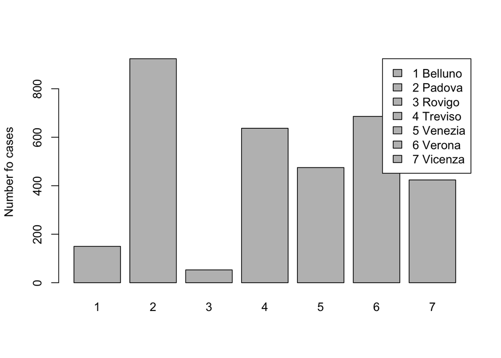

The number of observed cases $y_i$ is very different among NUTS-3 regions.

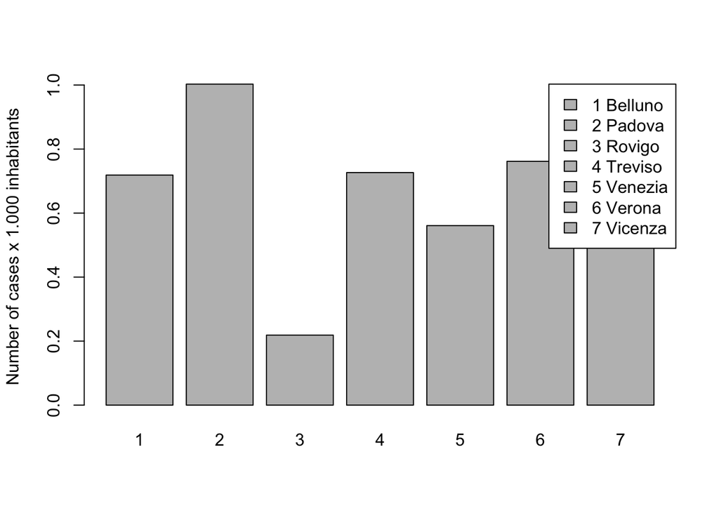

We create new variables that are required by INLA procedure.

```
##
## Call:
## c("inla(formula = formula.bym, family = \"poisson\", data = dat_csv, ",  "    E = pop, control.compute = list(dic = T))")
##
## Time used:
##  Pre-processing    Running inla Post-processing           Total
##          1.9381          0.6280          0.1329          2.6989
##
## Fixed effects:
##                 mean     sd 0.025quant 0.5quant 0.975quant     mode   kld
## (Intercept) -10.6482 0.1766   -11.0077 -10.6466   -10.2969 -10.6437 2e-04
##
## Random effects:
## Name   Model
##  ID   BYM model
##
## Model hyperparameters:
##                                         mean      sd 0.025quant 0.5quant
## Precision for ID (iid component)       6.301   3.493      1.782    5.585
## Precision for ID (spatial component) 909.213 910.048     61.980  639.640
##                                      0.975quant    mode
## Precision for ID (iid component)          15.09   4.194
## Precision for ID (spatial component)    3313.32 169.448
##
## Expected number of effective parameters(std dev): 6.86(0.0793)
## Number of equivalent replicates : 25.51
##
## Deviance Information Criterion (DIC) ...............: 4084.18
## Deviance Information Criterion (DIC, saturated) ....: 3483.80
## Effective number of parameters .....................: 6.989
##
## Marginal log-Likelihood:  -2054.94
## Posterior marginals for linear predictor and fitted values computed
```

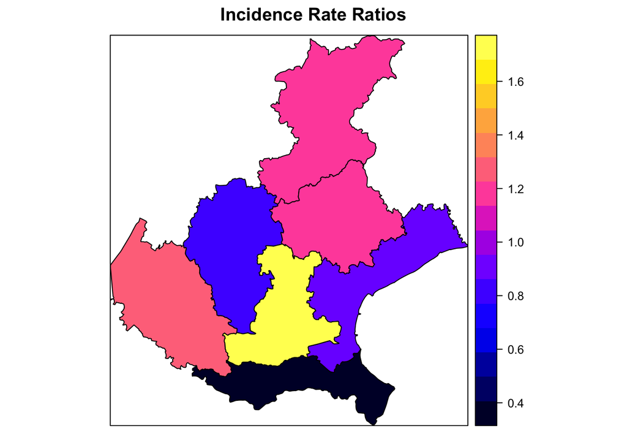

```
## [1] "Belluno" "Padova"  "Rovigo"  "Treviso" "Venezia" "Verona"  "Vicenza"
```

The image reported the IRR=exp($\mu_i$), the increase of the Incidence of Covid-19 in each NUTS-3 Region respect to the overall mean.

#Temporal model We consider the temporal aspect estimating a Bayesian RW2 model to model the temporal trend of COVID-19 in the reported temporal window. The observed number of COVID-19 a the time $t$, $y_{t}$, is modelled as follows
$$Y_t|\lambda_t\sim \mbox{Poisson}(\lambda_t), \qquad t=i,2,\ldots \\$$

with t=1,…,T, the quantity $\lambda_{t}$, is modelled by a Random Walk of order 2 (RW2) variable
$$log{\lambda_{it}}=\alpha+\gamma_t+\phi_t, \\$$

where $\alpha$ is the intercept, $\gamma_t \sim RW2$ are the coefficients related to the random walk process while $\phi_t \sim N(0, \tau_t^{-1})$ are the temporal specific random errors.

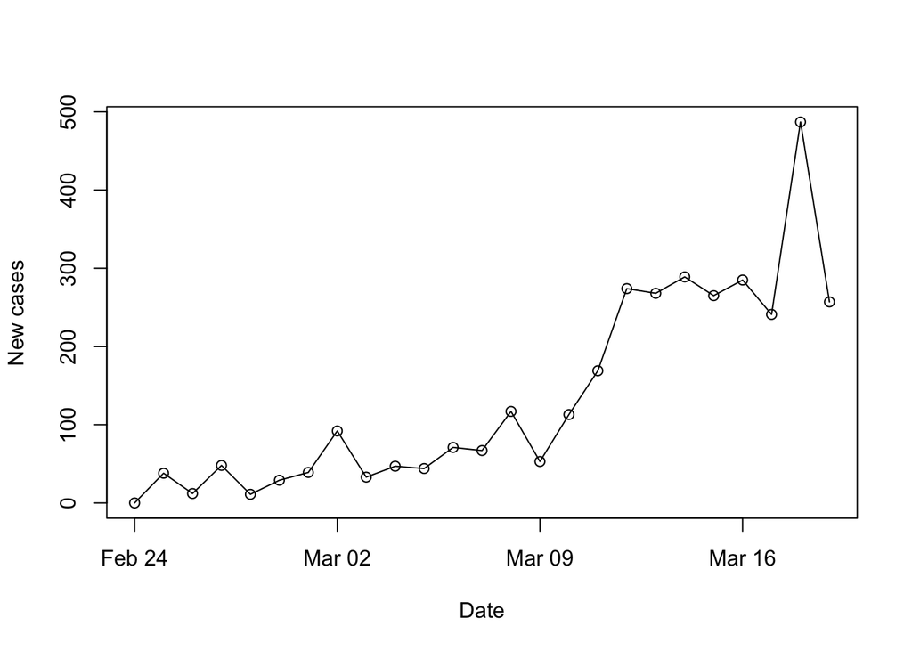

```
##
## Call:
## c("inla(formula = formula_t, family = \"poisson\", data = dat_csv, ",  "    control.compute = list(dic = T))")
##
## Time used:
##  Pre-processing    Running inla Post-processing           Total
##          1.8743          5.5899          0.1600          7.6242
##
## Fixed effects:
##               mean     sd 0.025quant 0.5quant 0.975quant   mode kld
## (Intercept) 1.2318 0.4165     0.4124   1.2323     2.0473 1.2336   0
##
## Random effects:
## Name   Model
##  t   RW2 model
## t2   IID model
##
## Model hyperparameters:
##                      mean       sd 0.025quant  0.5quant 0.975quant
## Precision for t  14847.02 14676.70    1273.86 10571.945  54085.815
## Precision for t2     4.63     1.68       2.12     4.377      8.613
##                      mode
## Precision for t  3600.508
## Precision for t2    3.896
##
## Expected number of effective parameters(std dev): 24.17(0.556)
## Number of equivalent replicates : 7.242
##
## Deviance Information Criterion (DIC) ...............: 2760.51
## Deviance Information Criterion (DIC, saturated) ....: 2160.13
## Effective number of parameters .....................: 23.19
##
## Marginal log-Likelihood:  -1435.55
## Posterior marginals for linear predictor and fitted values computed
```

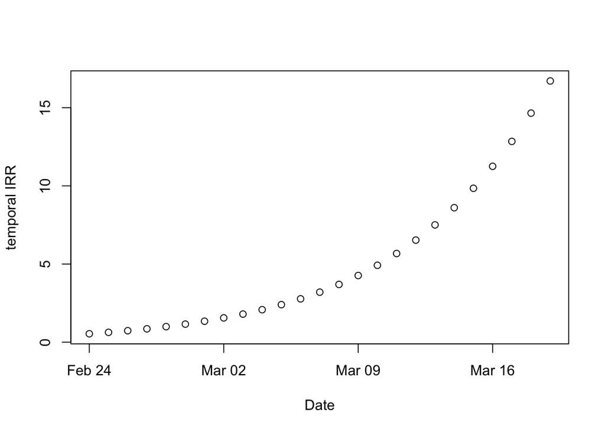

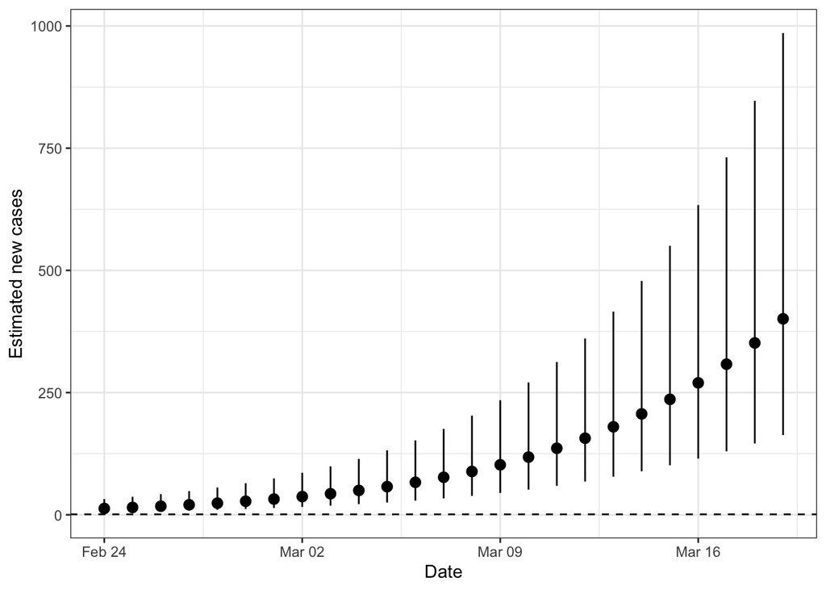

We now consider a BYM model with spatial and temporal components and their complete interactions (Type IV). The observed number of COVID-19, $y_{it}$, was modelled as:
$$Y_{it} \sim Poisson (\lambda_{it}), \\$$

with i=1,…,7and t=1,…,25.
We modelled the ratio $\frac{\lambda_{it}}{N_{i}}$, the Incidence of COVID-19, with a BYM model including temporal covariates as follows
$$log(\frac{\lambda_{it}}{N_{i}})=\alpha+\mu_i+\nu_i+\gamma_t+\phi_t+\delta_{it}, \\$$
where $\alpha$ is the intercept and:

- space: $\mu_i$ and $\nu_i$ are two area specific effects with normal distribution modelled using an intrinsic conditional autoregressive structure (iCAR);
- time:$\gamma_t \sim RW2$ are the coefficients related to the random walk process, while $\phi_t \sim N(0, \tau_t^{-1} )$ are the temporal specific random errors.
- space-time: $\delta_{it}$ are the coefficients related space-time interactions that in the its type 4 formulation (please see Spatial and Spatio-temporal Bayesian Models with R - INLA, Blangiardo and Cameletti) is made by the Kronecker product of time and space indexes.

```
##
## Call:
## c("inla(formula = formula.intIV, family = \"poisson\", data = dat_csv, ",  "    E = pop, control.compute = list(dic = T))")
##
## Time used:
##  Pre-processing    Running inla Post-processing           Total
##          3.4365          8.5171          0.1586         12.1121
##
## Fixed effects:
##                 mean     sd 0.025quant 0.5quant 0.975quant     mode   kld
## (Intercept) -11.7918 0.1826   -12.1981 -11.7768   -11.4747 -11.7516 1e-04
##
## Random effects:
## Name   Model
##  ID   BYM model
## t   RW2 model
## t2   IID model
## ID2   Besags ICAR model
##
## Model hyperparameters:
##                                           mean        sd 0.025quant
## Precision for ID (iid component)     1925.4118  1868.724   126.0966
## Precision for ID (spatial component) 1923.3671  1867.061   126.1462
## Precision for t                      5350.8102 47181.789    28.6828
## Precision for t2                        4.6093     1.943     1.9533
## Precision for ID2                       0.0414     0.017     0.0177
##                                       0.5quant 0.975quant     mode
## Precision for ID (iid component)     1375.6074  6.865e+03 342.0070
## Precision for ID (spatial component) 1374.0500  6.859e+03 342.1507
## Precision for t                       708.3690  3.582e+04  51.5084
## Precision for t2                        4.2340  9.427e+00   3.5878
## Precision for ID2                       0.0382  8.330e-02   0.0327
##
## Expected number of effective parameters(std dev): 98.21(5.759)
## Number of equivalent replicates : 1.782
##
## Deviance Information Criterion (DIC) ...............: 956.71
## Deviance Information Criterion (DIC, saturated) ....: 356.32
## Effective number of parameters .....................: 103.43
##
## Marginal log-Likelihood:  -924.76
## Posterior marginals for linear predictor and fitted values computed
```

The time and space component mean estimates can be extracted here

When can represent the IRR(=exp($\mu_i+\frac{1}{T} \sum_{i=t}^{T} \delta_{it}$)) for each NUTS-3 regions.

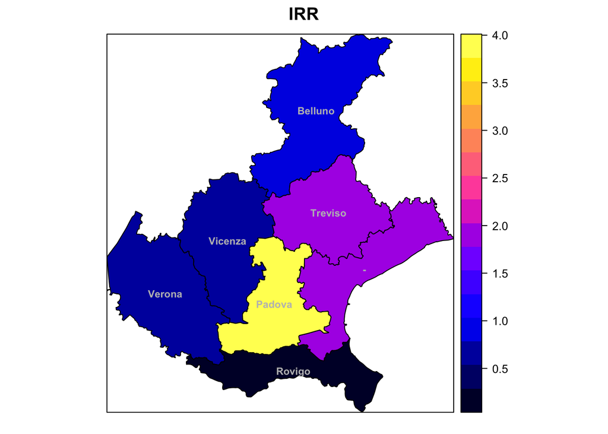

Trend for each province is reported below.

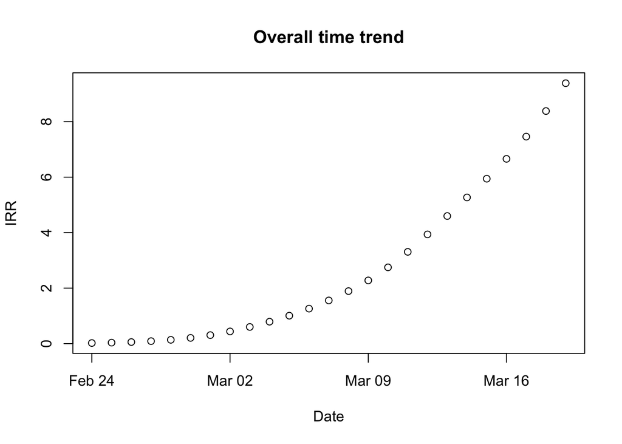

[interactive chart not shown]

#Predictions 3 days forward of new COVID-19 cases We made a forecast of 3 days forward on the number of COVID19 by means of BYM model and considering as covariate the number of Hubei epidemic lagged of 8 days because the different moment of restrictive measures between Italy and Hubei.

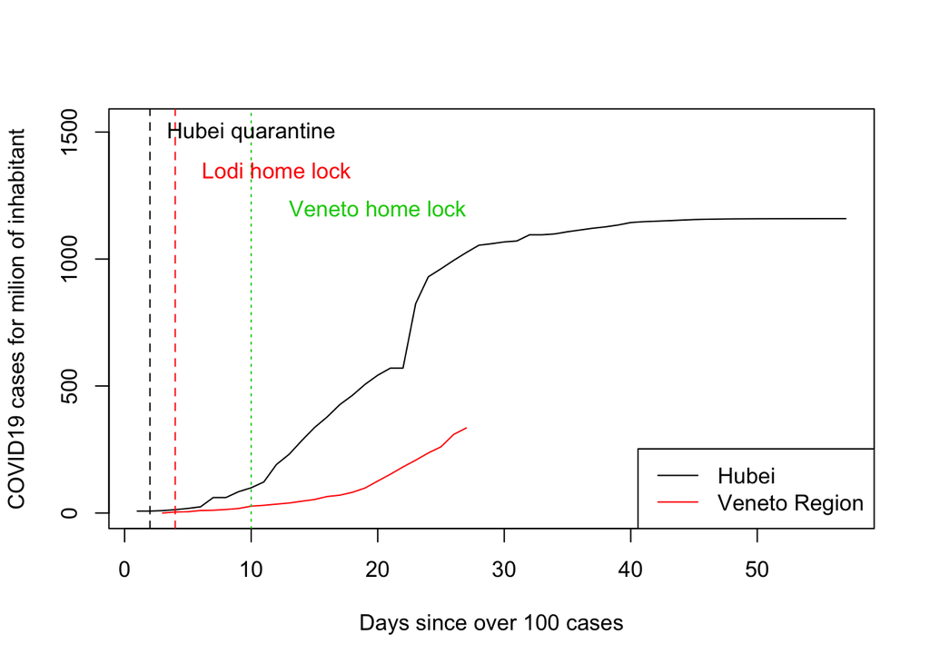

We model the number of cases.

```
##
## Call:
## c("inla(formula = formula.intIVn, family = \"poisson\", data = dat_csv_n, ",  "    control.compute = list(dic = T), control.predictor = list(link = 1))" )
##
## Time used:
##  Pre-processing    Running inla Post-processing           Total
##          3.8847         48.3466          0.1720         52.4033
##
## Fixed effects:
##                  mean     sd 0.025quant 0.5quant 0.975quant   mode kld
## (Intercept)    0.5696 0.4635    -0.3407   0.5697     1.4786 0.5700   0
## log(hubei + 1) 0.0472 0.0414    -0.0321   0.0464     0.1308 0.0448   0
## log(pop)       0.0477 0.0348    -0.0207   0.0477     0.1160 0.0477   0
##
## Random effects:
## Name   Model
##  t   RW2 model
## t2   IID model
## over   IID model
## ID   BYM model
## ID2   Besags ICAR model
##
## Model hyperparameters:
##                                          mean        sd 0.025quant
## Precision for t                      9500.640 10946.771    301.738
## Precision for t2                        9.382     6.245      2.742
## Precision for over                      4.439     1.077      2.698
## Precision for ID (iid component)     1877.053  1843.130    127.113
## Precision for ID (spatial component) 1880.101  1844.559    126.566
## Precision for ID2                     124.376   119.449     10.880
##                                      0.5quant 0.975quant    mode
## Precision for t                      5915.672  39292.321 591.535
## Precision for t2                        7.707     25.810   5.491
## Precision for over                      4.312      6.908   4.071
## Precision for ID (iid component)     1333.819   6750.671 347.550
## Precision for ID (spatial component) 1336.353   6758.764 346.243
## Precision for ID2                      90.005    443.014  30.916
##
## Expected number of effective parameters(std dev): 115.62(4.56)
## Number of equivalent replicates : 1.514
##
## Deviance Information Criterion (DIC) ...............: 928.18
## Deviance Information Criterion (DIC, saturated) ....: 327.79
## Effective number of parameters .....................: 111.53
##
## Marginal log-Likelihood:  -987.43
## Posterior marginals for linear predictor and fitted values computed
```

[interactive chart not shown]